# R Notebook: Binary choice modeling

## Packages

Make sure the following packages are installed before proceeding:

1. ggplot2
2. ggthemes
3. xtable
4. knitr
5. caret
6. e1071
7. pROC

```r
library("xtable") # processing of regression output
library("knitr") # used for report compilation and table display
library("ggplot2") # very popular plotting library ggplot2
library("ggthemes") # themes for ggplot2
library("caret") # confusion matrix
library("pROC") # confusion matrix
```

## Binary choice modeling

This notebook shows how to estimate a simple binary choice model, interpret it, and use it to make predictions about consumer behavior.

## Reading data

Let us load the data first.

```r
RFMdata <- read.csv(file = "./data/RFMData.csv",row.names=1)
kable(head(RFMdata,5),row.names = TRUE)
```

|  | Recency | Frequency | Monetary | Purchase |
| --- | --- | --- | --- | --- |
| 1 | 120 | 7 | 41.66 | 0 |
| 2 | 90 | 9 | 46.71 | 0 |
| 3 | 120 | 6 | 103.99 | 1 |
| 4 | 270 | 17 | 37.13 | 1 |
| 5 | 60 | 5 | 88.92 | 0 |

Each row (observation) is a separate customer who has transacted at least once before. The columns (variables) are:

1. Recency – how many days since last purchase
2. Frequency – how many times the consumer buys per year
3. Monetary – total $ amount spent per year
4. Purchase - (yes/no) whether purchase occurred

## Naive model

Now, let us draw a scatter plot of purchase occurrences (y-axis) by recency (x-axis). We will also overlay on top a regression line through the cloud of points that is based on equation

$$Purchase_i=\beta_0+\beta_1Recency_i$$
We estimate parameters $\beta_0,\beta_1$ using ordinary least squares – lm() function below. Then we plot everything using ggplot2 package, and use ggthemes to make the plot look nice.

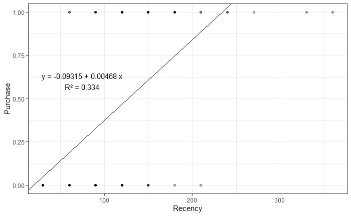

```r
model <- lm(data=RFMdata, Purchase ~ Recency) # note, lm() automatically includes intercept

# coef(model)[1] is beta0
# coef(model)[2] is beta1

p <- ggplot(RFMdata, aes(Recency, Purchase)) +
  geom_point(alpha=0.3) + # draws points
  theme_bw() # changes visual theme of the plot to make the look cleaner

p + geom_abline(intercept = coef(model)[1], # setting intercept of the line based on beta0
                slope = coef(model)[2]) + # setting slope of the line based on beta1
  # annotating
  annotate(label = sprintf("y = %.5f + %.5f x\nR² = %.3f", coef(model)[1],coef(model)[2],  summary(model)$r.squared), geom = "text", x = 75, y = 0.6, size = 4)
```

## A better choice model – Logit

A better model is logit, which restricts the output values to lie in $[0,1]$ interval.

Specifically, it expresses probability of a purchase by customer $i$ as a function of coefficients $\beta_{0:3}$ and variables in the following manner:
$$P(Purchase_i) = \frac{\exp(\beta_0 + \beta_1Recency_i + \beta_2Frequency_i+\beta_3Monetary_i)}{\exp(\beta_0 + \beta_1Recency_i + \beta_2Frequency_i+\beta_3Monetary_i) + 1}$$
Intuitively, utility of *choosing to buy* is
$$V_{bi} = \beta_0 + \beta_1Recency_i + \beta_2Frequency_i+\beta_3Monetary_i$$
whereas utility of *choosing **not** to buy* is normalized to zero $V_{ni}=0$, so $exp(V_{n})=exp(0)=1$ in the fraction above.

With the given formulation, we can estimate values $\beta_{0:3}$ that fit data best. We use glm() of family=“binomial”.

```r
model <- glm(Purchase~Recency+Frequency+Monetary, data=RFMdata, family = "binomial")
output <- cbind(coef(summary(model))[, 1:4],exp(coef(model)))
colnames(output) <- c("beta","SE","z val.","Pr(>|z|)",'exp(beta)')
kable(output,caption = "Logistic regression estimates")
```

|  | beta | SE | z val. | Pr(>\|z\|) | exp(beta) |
| --- | --- | --- | --- | --- | --- |
| (Intercept) | -30.2976692 | 8.5522913 | -3.542638 | 0.0003961 | 0.000000 |
| Recency | 0.1114175 | 0.0309797 | 3.596464 | 0.0003226 | 1.117862 |
| Frequency | 0.5941268 | 0.2429393 | 2.445577 | 0.0144620 | 1.811448 |
| Monetary | 0.1677054 | 0.0465645 | 3.601572 | 0.0003163 | 1.182588 |

We also run the likelihood ratio test with $H_0:\beta_1=\beta_2=\beta_3=0$ – to make sure our full logit model offers a significantly better fit than the model with just an intercept. We find that $\chi^2=107.14$ and $P(>|Chi|)\approx 0$, so we reject $H_0$.

```r
# likelihood ratio test
reduced.model <- glm(Purchase ~ 1, data=RFMdata, family = "binomial")
kable(xtable(anova(reduced.model, model, test = "Chisq")),caption = "Likelihood ratio test")
```

| Resid. Df | Resid. Dev | Df | Deviance | Pr(>Chi) |
| --- | --- | --- | --- | --- |
| 99 | 137.62776 | NA | NA | NA |
| 96 | 30.48715 | 3 | 107.1406 | 0 |

## Predicting probabilities

Now we calculate $P(Purchase_i)$ for each individual in the data set.

```r
# calculate logit probabilities
RFMdata$Base.Probability <- predict(model, RFMdata, type="response")
kable(head(RFMdata,5),row.names = TRUE)
```

|  | Recency | Frequency | Monetary | Purchase | Base.Probability |
| --- | --- | --- | --- | --- | --- |
| 1 | 120 | 7 | 41.66 | 0 | 0.0030728 |
| 2 | 90 | 9 | 46.71 | 0 | 0.0008332 |
| 3 | 120 | 6 | 103.99 | 1 | 0.9833225 |
| 4 | 270 | 17 | 37.13 | 1 | 0.9999999 |
| 5 | 60 | 5 | 88.92 | 0 | 0.0032378 |

## Predicting behavior

We also calculate an indicator variable for whether individuals will purchase or not, based on their predicted probabilities
$$\mathbb{1}[P(Purchase_i)\geq 0.5]$$
If individual’s predicted probability is greater or equal to 0.5, we predict he will make a purchase.

```r
# purchase vs. no purchase <-> p>0.5 or p<0.5
RFMdata$Predicted.Purchase <- 1*(RFMdata$Base.Probability>=0.5)
kable(head(RFMdata,5),row.names = TRUE)
```

|  | Recency | Frequency | Monetary | Purchase | Base.Probability | Predicted.Purchase |
| --- | --- | --- | --- | --- | --- | --- |
| 1 | 120 | 7 | 41.66 | 0 | 0.0030728 | 0 |
| 2 | 90 | 9 | 46.71 | 0 | 0.0008332 | 0 |
| 3 | 120 | 6 | 103.99 | 1 | 0.9833225 | 1 |
| 4 | 270 | 17 | 37.13 | 1 | 0.9999999 | 1 |
| 5 | 60 | 5 | 88.92 | 0 | 0.0032378 | 0 |

## Evaluating the model

Now we compute a *confusion matrix* between predicted purchases and actual purchase behavior.

```r
confusionMatrix(table(RFMdata$Predicted.Purchase,RFMdata$Purchase),positive = "1")
```

```
Confusion Matrix and Statistics


     0  1
  0 51  2
  1  4 43

               Accuracy : 0.94
                 95% CI : (0.874, 0.9777)
    No Information Rate : 0.55
    P-Value [Acc > NIR] : <2e-16

                  Kappa : 0.8793

 Mcnemar's Test P-Value : 0.6831

            Sensitivity : 0.9556
            Specificity : 0.9273
         Pos Pred Value : 0.9149
         Neg Pred Value : 0.9623
             Prevalence : 0.4500
         Detection Rate : 0.4300
   Detection Prevalence : 0.4700
      Balanced Accuracy : 0.9414

       'Positive' Class : 1
```

To note from output above: - Sensitivity is the true positive rate (Recall) - Specificity is the true negative rate () - 95% CI means that there is a 95% chance that the true hit rate/accuracy would be between 87.4% to 97.8% - No information rate means that if we do not include any of the RFM factors into the model, and blindy predict who would be in the larger group (did not buy), then the hit rate would be 55% - False positive = 1 - True negative rate

We can also plot the receiver operating characteristic (ROC) curve, which illustrates the diagnostic ability of a binary logit model. It is created by plotting the true positive rate (TPR) against the false positive rate (FPR) – at various decision threshold values for prediction.

ROC curve can be quickly evaluated using area under the curve (AUC) metric, which captures the overall quality of the classifier. The greater the AUC, the better. AUC of 1.0 represents a perfect classifier, AUC of 0.5 (diagonal line) represents a worthless classifier. As we see, binary logit classifier does a good job predicting purchases on the training data.

Note: AUC means that 98.3% of the time, a buyer will have a higher purchase probability than a non-buyer. Thus a good trust of the model regardless of the metric point.

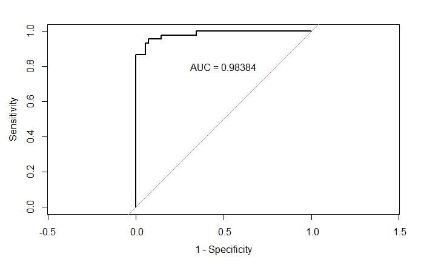

```r
rocobj <- roc(RFMdata$Purchase, RFMdata$Base.Probability)
{plot(rocobj,legacy.axes=TRUE)
text(0.5, 0.8, labels = sprintf("AUC = %.5f",rocobj$auc))}
```

Finally, we predict new probabilities under a hypothetical scenario that everyone’s *Monetary* variable went up by one unit
$$V_{bi}^{new} = \beta_0 + \beta_1Recency_i + \beta_2Frequency_i+\beta_3(Monetary_i+1)$$

```r
# calculate new logit probabilities (Monetary+1)
RFMdata_new <- RFMdata
RFMdata_new$Monetary <- RFMdata_new$Monetary + 1
RFMdata$New.Probability <- predict(model, RFMdata_new, type="response")
```

We compare mean new probability across individuals to the mean of old probabilities, and also calculate the lift metric.

$$p_{old}=\frac{1}{N}\sum_{i=1}^{N} P(Purchase_i) = \frac{1}{N}\sum_{i=1}^{N} \frac{\exp(V_{bi})}{\exp(V_{bi}) + 1}=\frac{1}{N}\sum_{i=1}^{N}\frac{\exp(\beta_0 + \beta_1Recency_i + \beta_2Frequency_i+\beta_3Monetary_i)}{\exp(\beta_0 + \beta_1Recency_i + \beta_2Frequency_i+\beta_3Monetary_i) + 1}$$
$$p_{new}=\frac{1}{N}\sum_{i=1}^{N} P(Purchase_i^{new}) = \frac{1}{N}\sum_{i=1}^{N} \frac{\exp(V_{bi}^{new})}{\exp(V_{bi}^{new}) + 1}=\frac{1}{N}\sum_{i=1}^{N}\frac{\exp(\beta_0 + \beta_1Recency_i + \beta_2Frequency_i+\beta_3(Monetary_i+1))}{\exp(\beta_0 + \beta_1Recency_i + \beta_2Frequency_i+\beta_3(Monetary_i+1)) + 1}$$

$$Lift = \frac{p_{new}-p_{old}}{p_{old}}$$

```r
# mean predicted base probability
mean(RFMdata$Base.Probability)
```

```
[1] 0.45
```

```r
# mean new predicted probability
mean(RFMdata$New.Probability)
```

```
[1] 0.4578851
```

```r
# lift
(mean(RFMdata$New.Probability) - mean(RFMdata$Base.Probability))/mean(RFMdata$Base.Probability)
```

```
[1] 0.01752255
```

```r
# remove predicted purchase variable
RFMdata$Predicted.Purchase <- NULL

# data
kable(head(RFMdata,5),row.names = TRUE)
```

|  | Recency | Frequency | Monetary | Purchase | Base.Probability | New.Probability |
| --- | --- | --- | --- | --- | --- | --- |
| 1 | 120 | 7 | 41.66 | 0 | 0.0030728 | 0.0036319 |
| 2 | 90 | 9 | 46.71 | 0 | 0.0008332 | 0.0009852 |
| 3 | 120 | 6 | 103.99 | 1 | 0.9833225 | 0.9858611 |
| 4 | 270 | 17 | 37.13 | 1 | 0.9999999 | 0.9999999 |
| 5 | 60 | 5 | 88.92 | 0 | 0.0032378 | 0.0038267 |